# Análisis de Componentes Principales (PCA)

# Introdución a PCA

PCA es una manera particular de trabajar con datasets donde no es facil manipularlos por su dimensionalidad.

En muchas ocaciones, tenemos muchas variables presentes.

Y no es facil presentar los datos en su formato crudo. Por lo que el PCA nos permite ver la forma de nuestros datos para poder identificar que muestras o bariables son similares una con otra y cuales son muy diferentes

Esto facilita la identificacion de grupos de muestra que son similares y trabajar con las variables que hacen diferente a un grupo de otro.

# Objetivos de PCA

- Reducir el número de variables originales ($X_1, X_2,...,X_n$) a un número menor de variables ($CP_1, CP_2,...,CP_p$), denominadas componentes principales

Las matemáticas subyacentes son algo complejas, por lo que no entraré en demasiados detalles, pero los conceptos básicos de PCA son los siguientes:

- Toma un conjunto de datos con muchas variables
- Simplifica ese conjunto de datos al convertir sus variables originales en un número más pequeño de "Componentes principales".

# ¿Qué es un Componente Principal?

**Componentes principales:** Es una combinación lineal de las variables iniciales y sintetizan la mayor parte de la información contenida en los datos originales (varianza total o Inercia)

Pero, ¿qué son estos exactamente?

Los componentes principales son la estructura subyacente en los datos. **Son las direcciones donde hay más variación, las direcciones donde los datos están más dispersos**.

# Caracteristicas

- Cuando **muchas variables se correlacionan entre sí**, todas contribuirán fuertemente al **mismo componente principal**.
- Cada **componente principal resume un cierto porcentaje** de la variación total en el conjunto de datos.
- Cuando sus variables iniciales estén **fuertemente correlacionadas entre sí**, podrá aproximar la mayor parte de la complejidad de su conjunto de datos con solo unos **pocos componentes principales**.

# Eigenvalores y Eigenvectores

Al igual que muchas cosas en la vida, los eigenvectores y los eigenvalores vienen en pares:

> Cada eigenvector tiene un eigenvalor correspondiente.

Un eigenvector es una dirección, como "vertical" o "45 grados", mientras que un eigenvalor es un número que le indica cuánta varianza hay en los datos en esa dirección.

**El eigenvector con el valor propio más alto es, por lo tanto, el primer componente principal**.

**El número de eigenvalores y eigenvectores es igual al número de dimensiones que tiene el conjunto de datos.**

# Reducción de Dimensión

Podemos replantear un conjunto de datos en términos de estos eigenvectores y eigenvalores sin cambiar la información subyacente.

Tenga en cuenta que volver a enmarcar un conjunto de datos con respecto a un conjunto de eigenvalores y eigenvectores no implica cambiar los datos en sí, solo lo está mirando desde un ángulo diferente, lo que debería representar mejor los datos.

# Ejemplo

Realizaremos un PCA utilizando un conjunto de datos simple y fácil de entender.

`mtcars`

Este conjunto de datos consta de datos sobre 32 modelos de automóviles, tomados de una revista estadounidense de automovilismo (1974 Motor Trend magazine). Para cada automóvil, tiene 11 características, expresadas en unidades variables (unidades de EE. UU.).

# `mtcars`

- **mpg:** Consumo de combustible (millas por galón (EE. UU.)): los automóviles más potentes y pesados tienden a consumir más combustible.
- **cyl:** Número de cilindros: los automóviles más potentes suelen tener más cilindros
- **disp:** Desplazamiento (cu.in.): el volumen combinado de los cilindros del motor
- **hp:** Potencia bruta: esta es una medida de la potencia generada por el automóvil
- **drat:** Relación del eje trasero: describe cómo un giro del eje de transmisión corresponde a un giro de las ruedas. Los valores más altos disminuirán la eficiencia del combustible.
- **wt:** Peso (1000 lbs)
- **qsec:** 1/4 de milla de tiempo: la velocidad y aceleración de los autos
- **vs:** Bloqueo del motor: indica si el motor del vehículo tiene la forma de una "V" o si tiene una forma recta más común.
- **am:** Transmisión: indica si la transmisión del automóvil es automática (0) o manual (1).
- **gear:** Número de marchas hacia adelante: los autos deportivos tienden a tener más marchas.
- **carb:** Número de carburadores: asociado con motores más potentes

```r
mtcars
# Notar las unidades varian y cupan diferentes escalas

# Quitar las variables que son factores
```

A data.frame: 32 × 11

|  | mpg <dbl> | cyl <dbl> | disp <dbl> | hp <dbl> | drat <dbl> | wt <dbl> | qsec <dbl> | vs <dbl> | am <dbl> | gear <dbl> | carb <dbl> |
| --- | --- | --- | --- | --- | --- | --- | --- | --- | --- | --- | --- |
| Mazda RX4 | 21.0 | 6 | 160.0 | 110 | 3.90 | 2.620 | 16.46 | 0 | 1 | 4 | 4 |
| Mazda RX4 Wag | 21.0 | 6 | 160.0 | 110 | 3.90 | 2.875 | 17.02 | 0 | 1 | 4 | 4 |
| Datsun 710 | 22.8 | 4 | 108.0 | 93 | 3.85 | 2.320 | 18.61 | 1 | 1 | 4 | 1 |
| Hornet 4 Drive | 21.4 | 6 | 258.0 | 110 | 3.08 | 3.215 | 19.44 | 1 | 0 | 3 | 1 |
| Hornet Sportabout | 18.7 | 8 | 360.0 | 175 | 3.15 | 3.440 | 17.02 | 0 | 0 | 3 | 2 |
| Valiant | 18.1 | 6 | 225.0 | 105 | 2.76 | 3.460 | 20.22 | 1 | 0 | 3 | 1 |
| Duster 360 | 14.3 | 8 | 360.0 | 245 | 3.21 | 3.570 | 15.84 | 0 | 0 | 3 | 4 |
| Merc 240D | 24.4 | 4 | 146.7 | 62 | 3.69 | 3.190 | 20.00 | 1 | 0 | 4 | 2 |
| Merc 230 | 22.8 | 4 | 140.8 | 95 | 3.92 | 3.150 | 22.90 | 1 | 0 | 4 | 2 |
| Merc 280 | 19.2 | 6 | 167.6 | 123 | 3.92 | 3.440 | 18.30 | 1 | 0 | 4 | 4 |
| Merc 280C | 17.8 | 6 | 167.6 | 123 | 3.92 | 3.440 | 18.90 | 1 | 0 | 4 | 4 |
| Merc 450SE | 16.4 | 8 | 275.8 | 180 | 3.07 | 4.070 | 17.40 | 0 | 0 | 3 | 3 |
| Merc 450SL | 17.3 | 8 | 275.8 | 180 | 3.07 | 3.730 | 17.60 | 0 | 0 | 3 | 3 |
| Merc 450SLC | 15.2 | 8 | 275.8 | 180 | 3.07 | 3.780 | 18.00 | 0 | 0 | 3 | 3 |
| Cadillac Fleetwood | 10.4 | 8 | 472.0 | 205 | 2.93 | 5.250 | 17.98 | 0 | 0 | 3 | 4 |
| Lincoln Continental | 10.4 | 8 | 460.0 | 215 | 3.00 | 5.424 | 17.82 | 0 | 0 | 3 | 4 |
| Chrysler Imperial | 14.7 | 8 | 440.0 | 230 | 3.23 | 5.345 | 17.42 | 0 | 0 | 3 | 4 |
| Fiat 128 | 32.4 | 4 | 78.7 | 66 | 4.08 | 2.200 | 19.47 | 1 | 1 | 4 | 1 |
| Honda Civic | 30.4 | 4 | 75.7 | 52 | 4.93 | 1.615 | 18.52 | 1 | 1 | 4 | 2 |
| Toyota Corolla | 33.9 | 4 | 71.1 | 65 | 4.22 | 1.835 | 19.90 | 1 | 1 | 4 | 1 |
| Toyota Corona | 21.5 | 4 | 120.1 | 97 | 3.70 | 2.465 | 20.01 | 1 | 0 | 3 | 1 |
| Dodge Challenger | 15.5 | 8 | 318.0 | 150 | 2.76 | 3.520 | 16.87 | 0 | 0 | 3 | 2 |
| AMC Javelin | 15.2 | 8 | 304.0 | 150 | 3.15 | 3.435 | 17.30 | 0 | 0 | 3 | 2 |
| Camaro Z28 | 13.3 | 8 | 350.0 | 245 | 3.73 | 3.840 | 15.41 | 0 | 0 | 3 | 4 |
| Pontiac Firebird | 19.2 | 8 | 400.0 | 175 | 3.08 | 3.845 | 17.05 | 0 | 0 | 3 | 2 |
| Fiat X1-9 | 27.3 | 4 | 79.0 | 66 | 4.08 | 1.935 | 18.90 | 1 | 1 | 4 | 1 |
| Porsche 914-2 | 26.0 | 4 | 120.3 | 91 | 4.43 | 2.140 | 16.70 | 0 | 1 | 5 | 2 |
| Lotus Europa | 30.4 | 4 | 95.1 | 113 | 3.77 | 1.513 | 16.90 | 1 | 1 | 5 | 2 |
| Ford Pantera L | 15.8 | 8 | 351.0 | 264 | 4.22 | 3.170 | 14.50 | 0 | 1 | 5 | 4 |
| Ferrari Dino | 19.7 | 6 | 145.0 | 175 | 3.62 | 2.770 | 15.50 | 0 | 1 | 5 | 6 |
| Maserati Bora | 15.0 | 8 | 301.0 | 335 | 3.54 | 3.570 | 14.60 | 0 | 1 | 5 | 8 |
| Volvo 142E | 21.4 | 4 | 121.0 | 109 | 4.11 | 2.780 | 18.60 | 1 | 1 | 4 | 2 |

# Calcular los componentes principales

Debido a que PCA funciona mejor con datos numéricos, excluirá las dos variables categóricas (vs y am). Le queda una matriz de 9 columnas y 32 filas.

La función `prcomp ()` calcula los componentes principales.

Esta función también establecerá dos argumentos, centro y escala, para que sean VERDADEROS. Entonces puede echar un vistazo a su objeto PCA con `summary()`.

```r
mtcars.pca <- prcomp(mtcars[,c(1:7,10,11)], center = TRUE,scale. = TRUE)
summary(mtcars.pca)
```

```
Importance of components:
                          PC1    PC2     PC3     PC4     PC5     PC6     PC7
Standard deviation     2.3782 1.4429 0.71008 0.51481 0.42797 0.35184 0.32413
Proportion of Variance 0.6284 0.2313 0.05602 0.02945 0.02035 0.01375 0.01167
Cumulative Proportion  0.6284 0.8598 0.91581 0.94525 0.96560 0.97936 0.99103
                          PC8     PC9
Standard deviation     0.2419 0.14896
Proportion of Variance 0.0065 0.00247
Cumulative Proportion  0.9975 1.00000
```

# Resultado

Se obtiene 9 componentes principales, a los que llama $PC_{1-9}$.

Cada uno de estos explica un porcentaje de la variación total en el conjunto de datos.

Es decir: $PC_1$ explica el $63%$ de la varianza total, lo que significa que casi dos tercios de la información en el conjunto de datos (9 variables) pueden ser encapsulados por ese único Componente Principal.

$PC_2$ explica el $23%$ de la varianza. Entonces, al conocer la posición de una muestra en relación con solo $PC_1$ y $PC_2$, puede obtener una visión muy precisa de su posición en relación con otras muestras, ya que solo $PC_1$ y $PC_2$ pueden explicar el $86%$ de la varianza.

```r
str(mtcars.pca)
```

```
List of 5
 $ sdev    : num [1:9] 2.378 1.443 0.71 0.515 0.428 ...
 $ rotation: num [1:9, 1:9] -0.393 0.403 0.397 0.367 -0.312 ...
  ..- attr(*, "dimnames")=List of 2
  .. ..$ : chr [1:9] "mpg" "cyl" "disp" "hp" ...
  .. ..$ : chr [1:9] "PC1" "PC2" "PC3" "PC4" ...
 $ center  : Named num [1:9] 20.09 6.19 230.72 146.69 3.6 ...
  ..- attr(*, "names")= chr [1:9] "mpg" "cyl" "disp" "hp" ...
 $ scale   : Named num [1:9] 6.027 1.786 123.939 68.563 0.535 ...
  ..- attr(*, "names")= chr [1:9] "mpg" "cyl" "disp" "hp" ...
 $ x       : num [1:32, 1:9] -0.664 -0.637 -2.3 -0.215 1.587 ...
  ..- attr(*, "dimnames")=List of 2
  .. ..$ : chr [1:32] "Mazda RX4" "Mazda RX4 Wag" "Datsun 710" "Hornet 4 Drive" ...
  .. ..$ : chr [1:9] "PC1" "PC2" "PC3" "PC4" ...
 - attr(*, "class")= chr "prcomp"
```

# Resultados del análisis `.pca`

- El punto central (`$center`), la escala (`$scale`), la desviación estándar (`sdev`) de cada componente principal
- La relación (correlación o anticorrelación, etc.) entre las variables iniciales y los componentes principales (`$rotación`)
- Los valores de cada muestra en términos de los componentes principales (`$x`)

# Presentación de PCA

Necesitamos instalar las librerias necesarias

```
install.packages(ggfortify)
library(ggfortify)

o

library(devtools)
install_github("vqv/ggbiplot")
```

# Biplot

La forma de gráficar es por un biplot, que incluye la posición de cada muestra en términos de PC1 y PC2.

También le mostrará cómo las variables iniciales se asignan.

Utilizará el paquete ggbiplot, que ofrece una función fácil de usar y bonita para trazar biplots.

Un biplot es un tipo de gráfico que le permitirá visualizar cómo se relacionan las muestras entre sí en nuestro PCA (qué muestras son similares y cuáles son diferentes) y revelará simultáneamente cómo cada variable contribuye a cada componente principal.

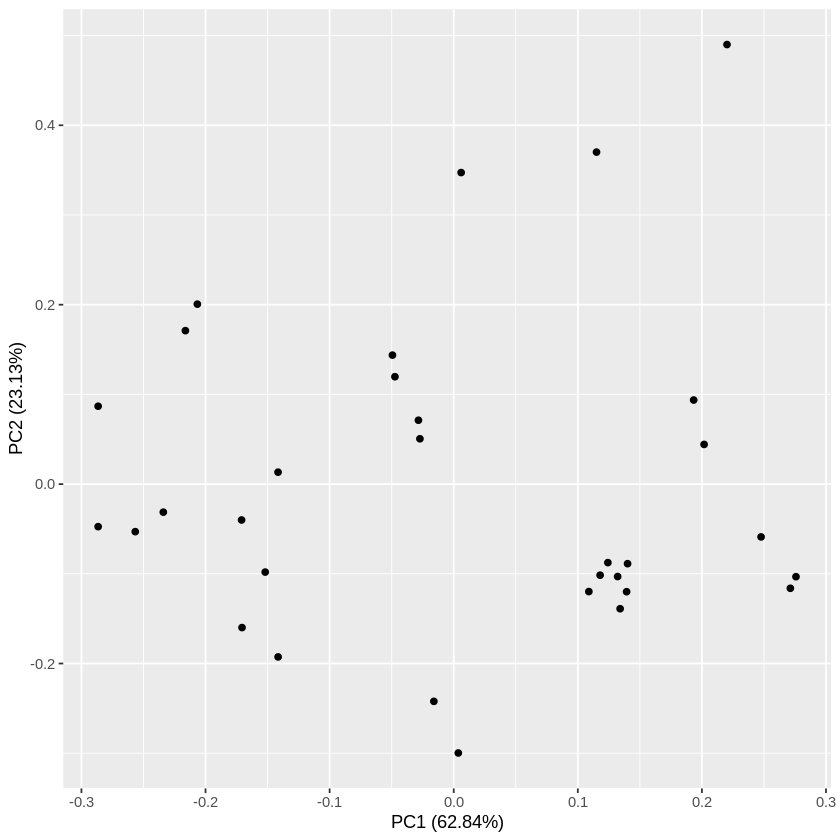

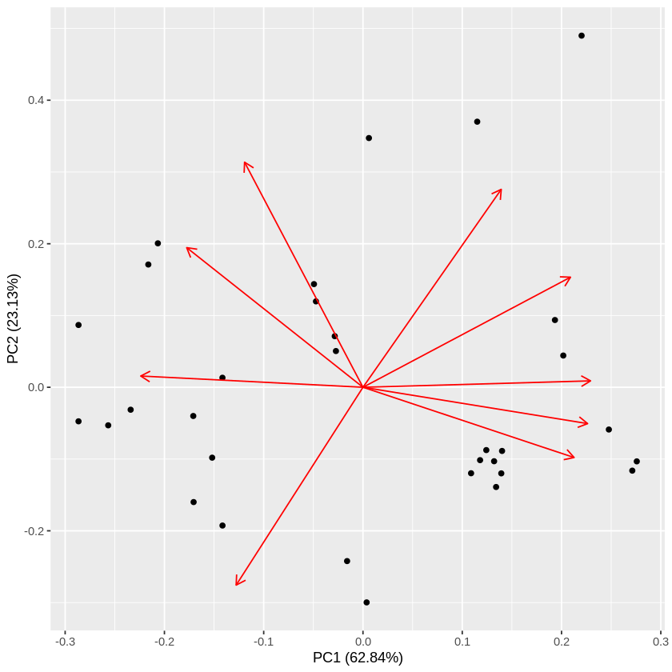

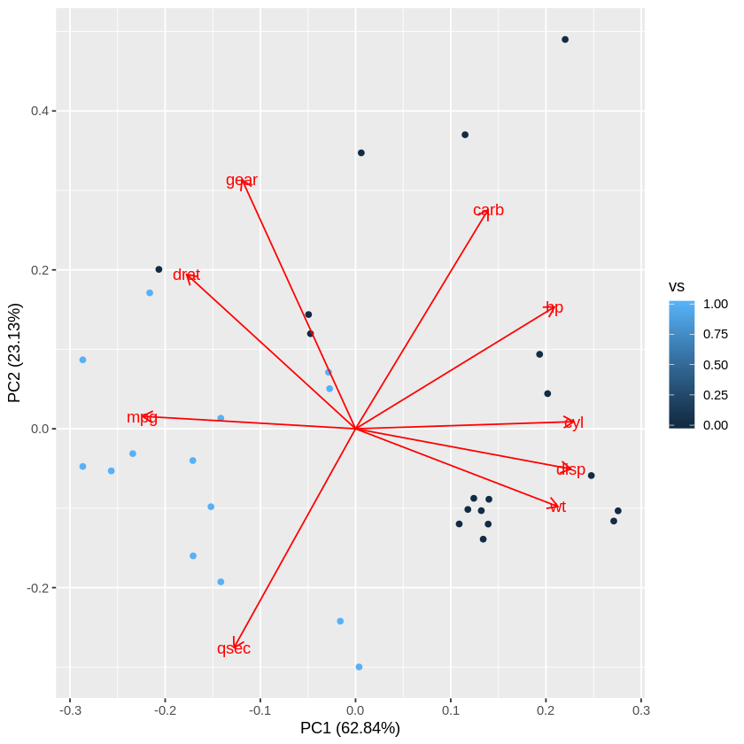

```r
library(ggfortify)
autoplot(mtcars.pca)
autoplot(mtcars.pca,data=mtcars,loadings=TRUE)
autoplot(mtcars.pca,data=mtcars,loadings=TRUE,colour = "vs",loadings.label = TRUE) # am
```

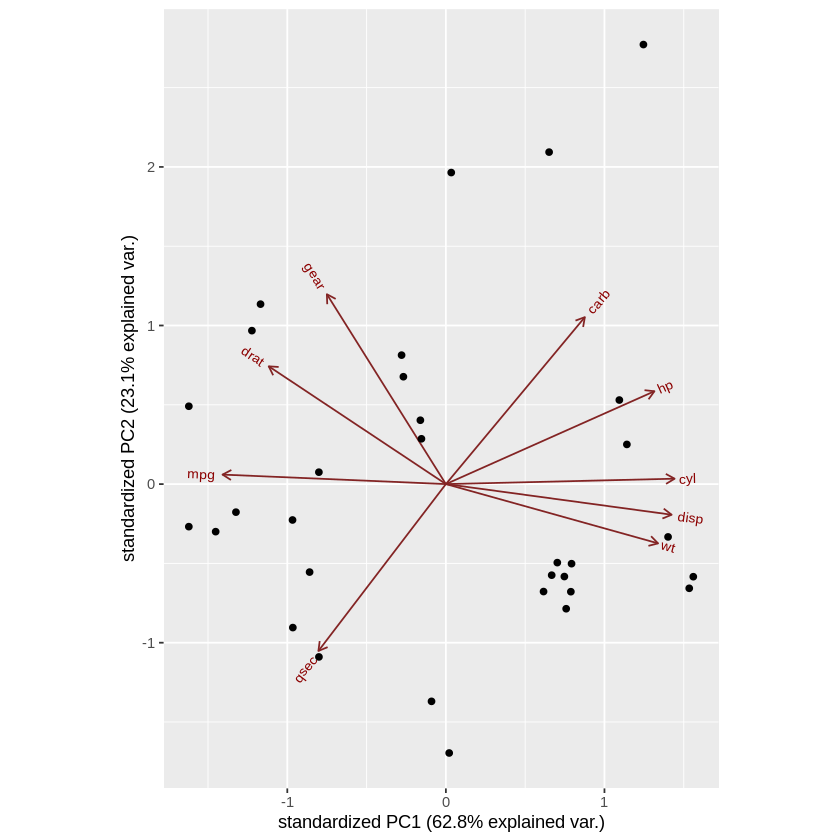

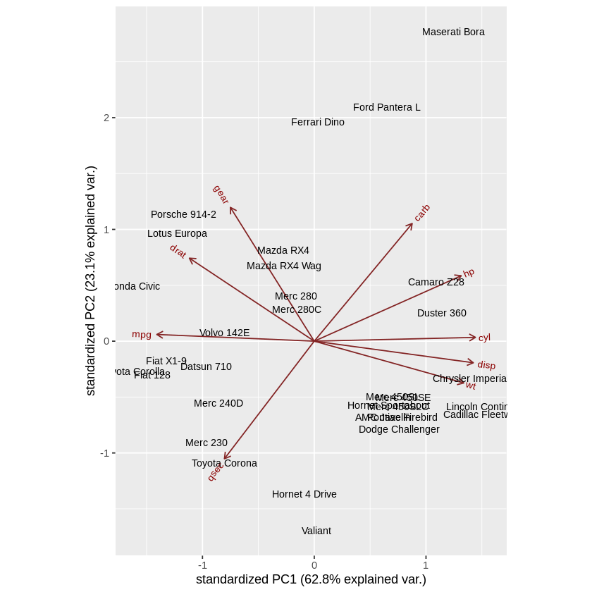

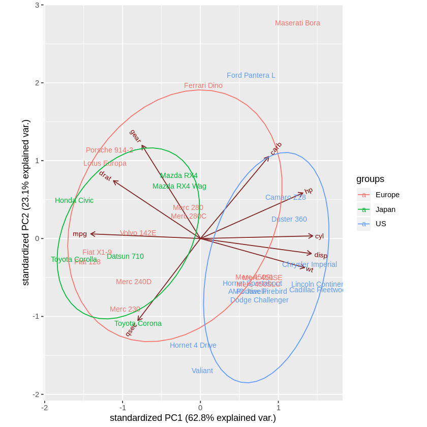

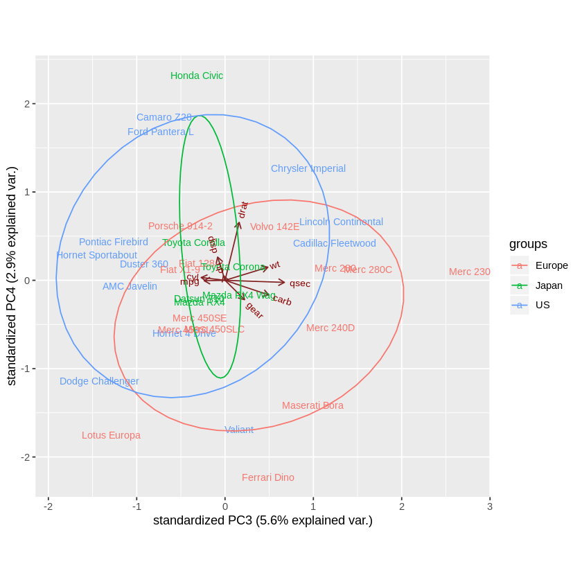

```r
library(ggbiplot)
ggbiplot(mtcars.pca)
ggbiplot(mtcars.pca, labels=rownames(mtcars))


mtcars.country <- c(rep("Japan", 3), rep("US",4), rep("Europe", 7),rep("US",3), "Europe", rep("Japan", 3), rep("US",4), rep("Europe", 3), "US", rep("Europe", 3))
ggbiplot(mtcars.pca,ellipse=TRUE,  labels=rownames(mtcars), groups=mtcars.country)

## PC3,4
ggbiplot(mtcars.pca,ellipse=TRUE,choices=c(3,4),   labels=rownames(mtcars), groups=mtcars.country)
```

Los ejes se ven como flechas que se originan desde el punto central. Aquí, verá que las variables hp, cyl y disp contribuyen a PC1, con valores más altos en esas variables que mueven las muestras hacia la derecha en este gráfico. Esto le permite ver cómo los puntos de datos se relacionan con los ejes, pero no es muy informativo sin saber qué punto corresponde a qué muestra (automóvil).

Ahora puede ver qué automóviles son similares entre sí. Por ejemplo, el Maserati Bora, Ferrari Dino y Ford Pantera L se agrupan en la parte superior. Esto tiene sentido, ya que todos estos son autos deportivos.

# Trabajo Final

Realiza lo mismo pero utilizando los datos de `iris`

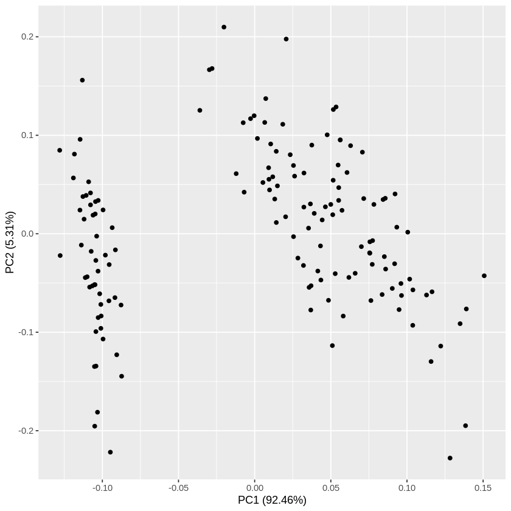

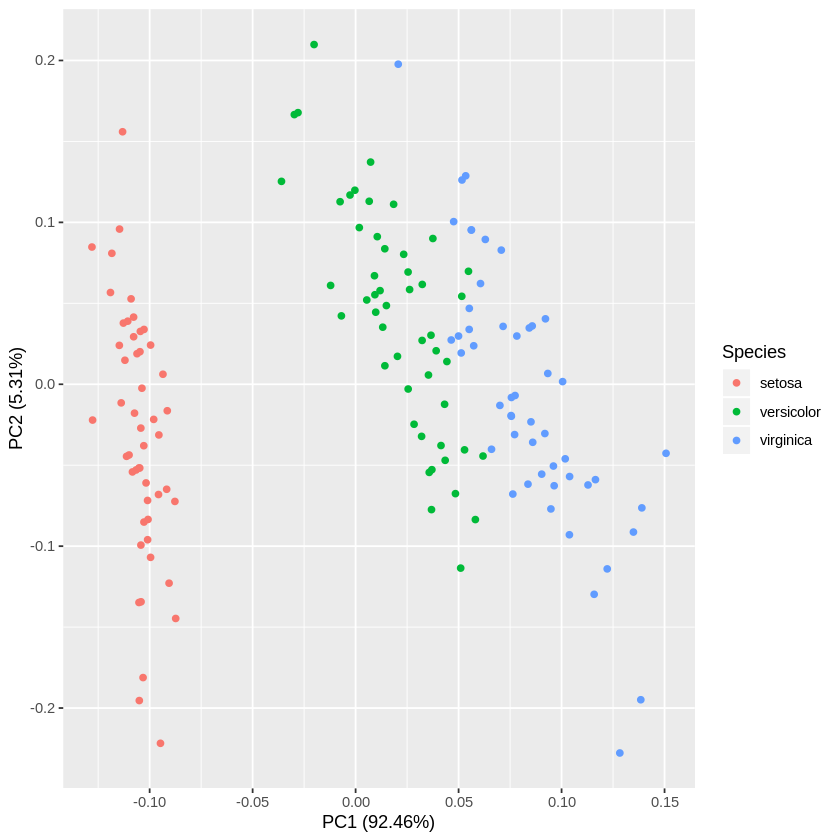

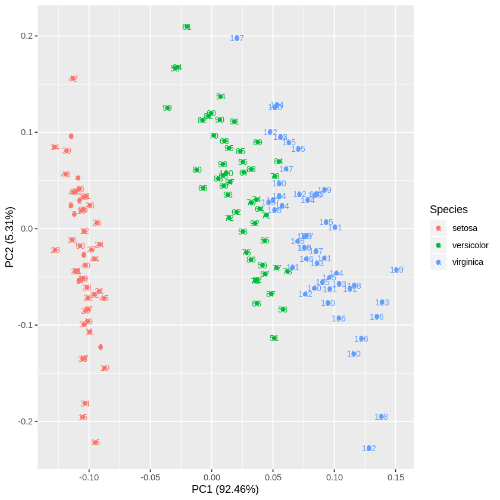

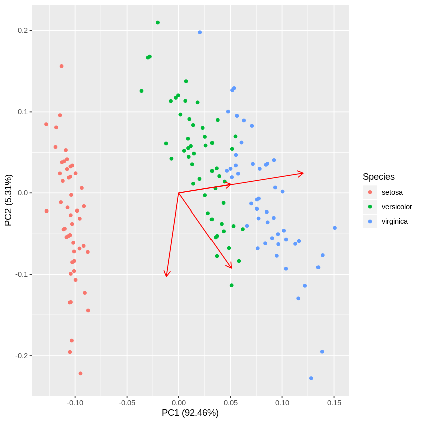

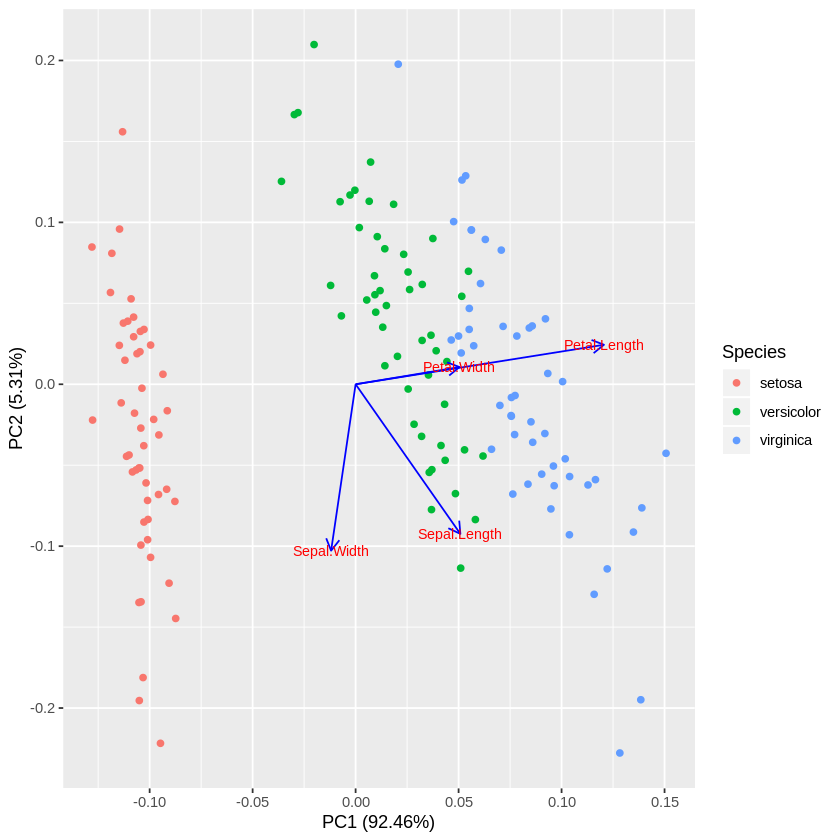

```r
df <- iris[c(1, 2, 3, 4)]

autoplot(prcomp(df))

autoplot(prcomp(df), data = iris, colour = 'Species')

autoplot(prcomp(df), data = iris, colour = 'Species', label = TRUE, label.size = 3)
autoplot(prcomp(df), data = iris, colour = 'Species', loadings = TRUE)

autoplot(prcomp(df), data = iris, colour = 'Species',
         loadings = TRUE, loadings.colour = 'blue',
         loadings.label = TRUE, loadings.label.size = 3)
```